# ROMOPOmics package

Andrew

5/3/2020

#ROMOPOmics

The purpose of ROMOPOmics is to incorporate the wide variety of sequencing-type data sets, including all pipeline by byproducts (alignment files, raw reads, readmes, etc.) as well as pipeline products of any type (gene counts, differential expression data, quality control analyses, etc.), into an SQL-friendly database that is easily accessed by users. The package should be a quick download that allows users to specify a data directory and a desired database name, a master file describing their desired SQL tables, and should allow users to build and update their existing SQL database at will

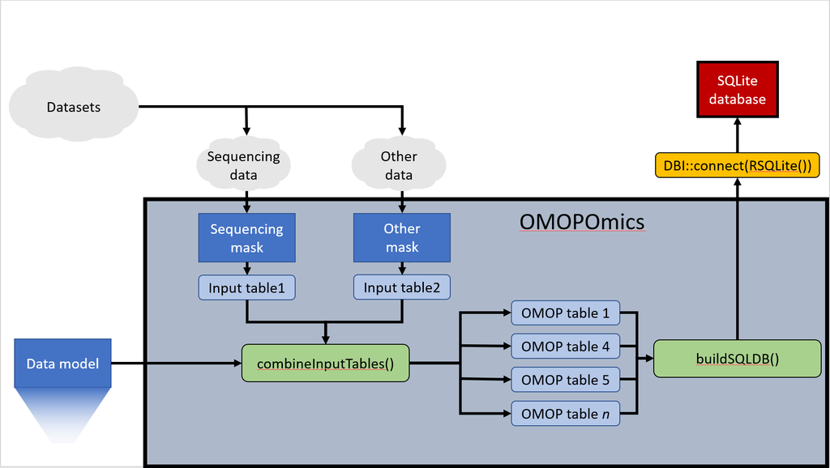

ROMOPOmics diagram

#Step 1: Install and load ROMOPOmics and its dependencies.

```r
library(ROMOPOmics)
```

#Step 2: Load the OMOP data model, in this case [OMOP 6.0](https://github.com/OHDSI/CommonDataModel/blob/master/OMOP_CDM_v6_0.csv).

> `loadDataModel()` can return the data model as a single table or as a list of OMOP tables.

```r
new_dm_file   <- file.path(dirs$base,"OMOP_CDM_v6_0_custom.csv")
old_dm_file   <- file.path(dirs$base,"OMOP_CDM_v6_0.csv")
dm      <- loadDataModel(as_table_list = FALSE,master_table_file = new_dm_file)
dm_lst  <- loadDataModel(as_table_list = TRUE,master_table_file = new_dm_file)
dm_old  <- loadDataModel(as_table_list = FALSE,master_table_file = old_dm_file)
```

Default OMOP values were downloaded from the [OMOP 6.0 GitHub](https://github.com/OHDSI/CommonDataModel/blob/master/OMOP_CDM_v6_0.csv). This data model includes 332 unique fields accross 38 tables:

| field | required | type | description | table |
| --- | --- | --- | --- | --- |
| cohort_definition_id | Yes | INTEGER | A foreign key to a record in the COHORT_DEFINITION table containing relevant Cohort Definition information. | cohort |
| subject_id | Yes | INTEGER | A foreign key to the subject in the cohort. These could be referring to records in the PERSON, PROVIDER, VISIT_OCCURRENCE table. | cohort |
| cohort_start_date | Yes | DATE | The date when the Cohort Definition criteria for the Person, Provider or Visit first match. | cohort |
| cohort_end_date | Yes | DATE | The date when the Cohort Definition criteria for the Person, Provider or Visit no longer match or the Cohort membership was terminated. | cohort |
| cohort_definition_id | Yes | INTEGER | A unique identifier for each Cohort. | cohort_definition |
| cohort_definition_name | Yes | VARCHAR(255) | A short description of the Cohort. | cohort_definition |
| cohort_definition_description | No | VARCHAR(MAX) | A complete description of the Cohort definition | cohort_definition |
| definition_type_concept_id | Yes | INTEGER | Type defining what kind of Cohort Definition the record represents and how the syntax may be executed | cohort_definition |
| … | … | … | … | … |

Our customized version of the OMOP data model includes two changes: First, an `hla_source_value` field is included in the `PERSON` table. This change should be self-explanatory, though it may be preferred that this value be recorded per-`Patient` as an observation in the `OBSERVATION` table by the strict standards of OMOP.

Second, our customized version includes a `SEQUENCING` table:

| field | required | type | description | table |
| --- | --- | --- | --- | --- |
| sequencing_id | Yes | INTEGER | A unique identifier for each sequencing entry. | sequencing |
| person_id | Yes | INTEGER | A foreign key identifier to the Person who is experiencing the condition. The demographic details of that Person are stored in the PERSON table. | sequencing |
| specimen_id | Yes | INTEGER | A unique identifier for each specimen. | sequencing |
| library_concept_value | Yes | VARCHAR(50) | Sequencing library type (text). | sequencing |
| library_source_value | No | VARCHAR(50) | Sequencing library source kit (text). | sequencing |
| library_paired_end | No | INTEGER | Boolean; library is paired end. | sequencing |
| library_cycles | No | INTEGER | Cycles per end; approximate number of base pairs sequenced per end of read. | sequencing |
| instrument_source_value | No | VARCHAR(50) | Sequencing platform used (text). | sequencing |
| reference_genome_value | No | VARCHAR(50) | Reference genome used, if aligned (text). | sequencing |
| metric_source_value | No | VARCHAR(50) | Units of sequencing data (text); i.e. what was sequenced. | sequencing |
| sequencing_pct_alignment | No | INTEGER | Percent alignment, if available. | sequencing |
| sequencing_min_quality | No | INTEGER | Minimum quality score, if available. | sequencing |
| sequencing_quality_metric | No | VARCHAR(50) | Quality score unit, if available. | sequencing |
| file_type_source_value | No | VARCHAR(50) | File type (text). | sequencing |
| sequencing_file_description | No | VARCHAR(255) | File description (counts, normalization method, differential analysis, etc.). | sequencing |
| file_local_source | No | VARCHAR(255) | Local file location. | sequencing |
| file_remote_repo_value | No | VARCHAR(50) | Remote file repository. | sequencing |
| file_remote_repo_id | No | VARCHAR(50) | Remote file repository ID. | sequencing |
| file_remote_source_url | No | VARCHAR(255) | Remote file URL. | sequencing |

This table inherits from `PERSON` and `SPECIMEN` currently, but this is changeable. I attempted to emulate the current OMOP model’s verbage as well, so these terms are not official. The reasons for including this table are two fold: First, sequencing data is excedingly common in contemporary research, and is increasingly common in personalized medicine techniques. Second, to be truly useful “Sequencing” data should be able to incorporate the spectrum of products along the testing pipeline, from library preparation to sequencing to data analysis. This will allow for intermediate steps and files to be used (getting and using raw files rather than the gene counts, for example). But crucially, this will facilitate comparisons using data sets between different studies, which must account for differences in library preparation, quality control, alignment methods, reference data, etc. Including this data should make this easier, but incorporating this variety of variables is not intuitive in the existing OMOP model.

#Step 3: Administrators design masks for data input.

```r
msks  <- loadModelMasks(mask_file_directory = file.path(dirs$base,"masks"))
```

“Masks” are designed to streamline the addition of existing data sets to OMOP format, or at least to how the *admin* thinks these data sets should be incorporated. The mask file provides `table`, `alias`, and `field` columns, which describe each term’s OMOP table, its name within the user’s input file, and its name within the standard OMOP field, respectively. For instance, `patient_name` in the user’s database will likely map to `person_source_value` in current OMOP parlance. Using multiple masks should streamline the use of multiple analysis types as well: the database administrators can develop and implement masks and users won’t need to know that `patient_name` and `cell_line_name` are both synonymous with `person_source_value` in the OMOP framework, for instance. Thus “Sequencing” data can be added using the `sequencing` mask, while “HLA”" data can be incorporated using an `hla` mask. Here’s an example of a `Sequencing` mask, provided to the `loadModelMasks()` function as a CSV:

| alias | table | field | description | example |
| --- | --- | --- | --- | --- |
| patient_name | PERSON | person_source_value | Patient name OR cell line/sample name. | Steven Stevenson |
| sex | PERSON | gender_source_value | Gender id value as text. | Male |
| hla_type | PERSON | hla_source_value | HLA type as string. | HLA-A*02:101:01:02N |
| collection_datetime | SPECIMEN | specimen_datetime | Date and time of collection. | 6/19/1986 4:30pm |
| sample_anatomy | SPECIMEN | anatomic_site_source_value | Anatomical location of collection as text from source. | appendix |
| disease_status | SPECIMEN | disease_status_source_value | Disease as text from source. | appendicitis |
| data_source | SPECIMEN | specimen_source_value | Value from the source dataset (mapped to Standard Concept in Standardized Vocab) | GEO1131223 |
| sequencing_library_type | SEQUENCING | library_concept_value | Sequencing library type (text). | smRNA |
| sequencing_library_kit | SEQUENCING | library_source_value | Sequencing library source kit (text) | miRNEasy miRNA kit |
| paired_end | SEQUENCING | library_paired_end | Boolean; library is paired end. | 0 |
| sequencing_cycles | SEQUENCING | library_cycles | Cycles per end; approximate number of base pairs sequenced per end of read. | 75 |
| sequencing_platform | SEQUENCING | instrument_source_value | Sequencing platform used (text). | Illumina NovaSeq 192 |
| reference_genome | SEQUENCING | reference_genome_value | Reference genome used, if aligned (text). | hg38 |
| sequencing_metric | SEQUENCING | metric_source_value | Units of sequencing data (text); i.e. what was sequenced. | smRNA transcripts |
| sequencing_pct_alignment | SEQUENCING | sequencing_pct_alignment | Percent alignment, if available. | 98 |
| sequencing_min_quality | SEQUENCING | sequencing_min_quality | Minimum quality score, if available. | 20 |
| sequencing_quality_metric | SEQUENCING | sequencing_quality_metric | Quality score unit, if available. | Phred |
| sequencing_file_type | SEQUENCING | file_type_source_value | File type (text). | BAM |
| sequencing_file_description | SEQUENCING | sequencing_file_description | File description (counts, normalization method, differential analysis, etc.). | Aligned reads, quality trimmed. |
| sequencing_file_location | SEQUENCING | file_local_source | Local file location. | C:/seq_data/seq1-1.bam |
| sequencing_repository | SEQUENCING | file_remote_repo_value | Remote file repository. | GEO |
| sequencing_repo_id | SEQUENCING | file_remote_repo_id | Remote file repository ID. | 999999 |
| sequencing_URL | SEQUENCING | file_remote_source_url | Remote file URL. | ftps:/remote_file/location/samp1.bam |
| sample_condition | CONDITION_OCCURRENCE | condition_type_value | Patient condition/cell line modeled. | Appendicitis. |
| cohort_name | COHORT_DEFINITION | cohort_definition_name | Short description of cohort. | Appendicitis smallRNA-seq |
| cohort_description | COHORT_DEFINITION | cohort_definition_description | Long description of cohort. | Patients with appendicitis had smRNA-seq libraries prepared from homogenized appendix biopsies. |
| cohort_definition_date | COHORT_DEFINITION | cohort_initiation_date | Date when the cohort was defined (as opposed to cohort time period, i.e. start and end datetimes). | 4/15/2019 |
| treatment_start_datetime | DRUG_EXPOSURE | drug_exposure_start_datetime | Treatment started. | 4/15/2019 3:30pm |
| treatment_end_datetime | DRUG_EXPOSURE | drug_exposure_end_datetime | Treatment ended. | 4/19/2019 1:30pm |
| drug_treatment | DRUG_EXPOSURE | drug_source_value | Drug treatment used. | Hydroxycut |
| drug_treatment_method | DRUG_EXPOSURE | route_source_value | Means of drug treatment. | IV drip. |
| drug_dose | DRUG_EXPOSURE | quantity | Quantity of drug administered. | 1.2 |
| drug_dose_unit | DRUG_EXPOSURE | dose_unit_source_value | Units describing treatment. | mg/kg |

Masks only need to include mapped OMOP values: if nothing is mapped to the `DRUG_ERA` field `gap_days`, it does not need to be included. So far the only requirement is that for a given mask, all aliases must be unique (otherwise it would be possible to have ambiguous mappings if the same field exists in multiple tables; think `unit_value`). Extra columns, such as `description` and `example` columns here, are ignored, which may be useful when developing Shiny apps or other such UI implementations of these masks.

#Step 4: Provide users with “masked” input options.

A UI can be designed here, but as a simple example in this case users can be provided a simple TSV that includes one column per dataset. Users fill in the masked fields in this file and then these files are stored in the sequencing data folder.

```r
lapply(names(msks), function(x) msks[[x]] %>%
  select(alias) %>%
  mutate(input= "") %>%
  write.table(file = file.path(dirs$base,paste0(x,"_input.tsv")),sep="\t",row.names = FALSE,col.names = FALSE))
```

#Step 5: Import all tables and convert them to OMOP-formatted tables.

Using the `readInputFiles()` function, data table inputs are translated into the OMOP format according to the provided `mask` (in this case `Sequencing`). This format is an “exhaustive” data table containing a row for every table/field combination in the data model (`dm`), including those not used in the mask. Every data set provided is assigned to a column, with `NA` for all empty values.

Since these tables are exhaustive and compatible with the original data model, at this point all tables can be combined (regardless of mask used) into a single OMOP table using `combineInputTables()`. This function combines all data sets from all mask types, and filters out all OMOP tables from the data model that are unused (no entries in any of the associated fields). Tables are not “partially” used; if any field is included from that table, all fields from that table are included. The only exception to this is table indices: if a table inherits an index from an unused table, that index column is dropped.

Once data has been loaded into a single comprehensive table, an index column (`<table_name>_index`) is assigned for each permutation of all data sets included in each used table, and formats the `type` of each column based on the data model’s specification (`VARCHAR(50)` is changed to “character”, `INTEGER` is changed to “integer”, etc.). Finally, this function returns each formatted OMOP table in a named list.

```r
seq_input_files <- Sys.glob(file.path(dirs$seq_data,"*.tsv"))
omop_tabs       <- lapply(seq_input_files,readInputFiles,data_model = dm,mask_table=msks$sequencing) %>%
                    combineInputTables()
```

In this example using this mask, the OMOP tables included are SPECIMEN, PERSON, COHORT_DEFINITION, CONDITION_OCCURRENCE, DRUG_EXPOSURE, and SEQUENCING.

#Step 6: Add OMOP-formatted tables to a database.

`Dplyr` has built-in SQLite functionality, which is used here. While size limitations may neccessitate Perl or C based database functions for larger databases, with smaller ones this package’s `buildSQLDBR()` function should suffice to add the formatted, indexed OMOP tables to a new SQLite database, and returns a connection to that database for queries.

```r
omop_db     <- buildSQLDBR(omop_tabs,sql_db_file = file.path(dirs$database,"sqlDB.sqlite"))
```

```r
dbListTables(omop_db)
```

```
## [1] "COHORT_DEFINITION"    "CONDITION_OCCURRENCE" "DRUG_EXPOSURE"
## [4] "PERSON"               "SEQUENCING"           "SPECIMEN"
## [7] "sqlite_stat1"         "sqlite_stat4"
```

```r
dbListFields(omop_db,"PERSON")
```

```
##  [1] "person_id"                   "birth_datetime"
##  [3] "day_of_birth"                "death_datetime"
##  [5] "ethnicity_concept_id"        "ethnicity_source_concept_id"
##  [7] "ethnicity_source_value"      "gender_concept_id"
##  [9] "gender_source_concept_id"    "gender_source_value"
## [11] "hla_source_value"            "month_of_birth"
## [13] "person_source_value"         "race_concept_id"
## [15] "race_source_concept_id"      "race_source_value"
## [17] "year_of_birth"
```

```r
dbGetQuery(omop_db,'SELECT person_source_value, person.person_id, file_local_source,file_type_source_value,file_remote_source_url
FROM person INNER JOIN sequencing
WHERE file_type_source_value = "Counts"')
```

```
##   person_source_value person_id     file_local_source file_type_source_value
## 1      Crystal Murphy         1 /sample/file/cnts.tsv                 Counts
## 2          Bill Smith         2 /sample/file/cnts.tsv                 Counts
## 3      Crystal Murphy         1 /sample/file/cnts.tsv                 Counts
## 4          Bill Smith         2 /sample/file/cnts.tsv                 Counts
##            file_remote_source_url
## 1 ftp://shd.med/9992914/smithbill
## 2 ftp://shd.med/9992914/smithbill
## 3 ftp://gfh.med/9992914/smithbill
## 4 ftp://gfh.med/9992914/smithbill
```